# Economy with avalanches

## Model

The model has $Q$ firms that buy and sell goods to each other (they need other goods to produce their own), and sell some of these goods to households that provide firms with labor.

The production $\pi_i$ of firm $i$ is given by:

$$ \pi_i = z_i\min_{j}(J_{ij}Q_j^i) $$

Where $J_{ij}$ is the input-output matrix (how much $i$ needs from $j$ in order to produce its goods), $Q_{j}^i$ is the quantity of goods that $i$ effectively buys from $j$ and $z_i$ is firm $i$'s productivity. This production function implies that goods **cannot be substituted**.

Assuming market clearing and competitive prices (zero-profits) for firms and utility maximization by the representative household leads to two equations :

$$ \mathbf{M}P = V \\ \mathbf{M}^t \lambda = \xi $$

where $P$ is the price vector and $\lambda$ the output vector, and $$ \mathbf{M}_{ij}= z_i\delta_{ij}-\frac{1}{J_{ij}}. $$ These equations should hold in some stationary state (no dynamics here yet).

### Parameters

We work with undirected graphs, so that $\frac{1}{J_{ij}}\neq 0 $ if $(i\leftrightarrow j)$ is in the production graph $\mathcal{G}$, and $\mathbf{M}=\mathbf{M}^t$.

Furthermore

$$ (i\leftrightarrow j)\in \mathcal{G} \implies \frac{1}{J_{ij}}=\left\{\begin{matrix} \frac{C}{Q} &\mbox{ with prob. } q \\ C\sigma &\mbox{ with prob. } 1-q \end{matrix}\right. $$

For $\mathcal{G}$, we take either an Erdös-Renyi graph with average connectivity $k$ (in which case the spectrum of $\mathbf{M}$ is in a band of width $\sigma Q$), or a Watts-Strogatz small-world graph of connectivity $k$ and rewiring probability $p$.

```python
import matplotlib.pyplot as plt
import numpy as np
import networkx as nx
import scipy.linalg as spla
import avalanches as av
%matplotlib inline
```

```python
C, sigma, Q = 2.0, 2.0, 200
q = 0.3
k = 3
p = 0.5
```

Phase diagram in $C/\sigma$ plane for Erdös-Renyi

[figure not shown]

and in $k/\sigma$ plane:

[figure not shown]

We start with a matrix $\mathbf{M}$ generated with the rule given previously, and productivities $z_i=(1,\ldots,1)$.

We first solve the equation $\mathbf{M}P=V$ and find how many $P_i$'s are negative. We interpret these to be bankrupted firms.

```python
econ1 = av.leontieff(1000,C,sigma,q,graph_type='erdos',k=k)
econ2 = av.leontieff(1000,C,sigma,q,graph_type='ws',k=k,p=p)
print "Erdos has {} negative prices".format(econ1.negs)
print "Watts-Strogatz has {} negative prices".format(econ2.negs)
```

```
Erdos has 1000 negative prices
Watts-Strogatz has 1000 negative prices
```

We 'stabilize' this by gradually increasing the productivity $z_i$ of firms with negative prices, until a state where $\forall i \quad P_i>0 $ is reached.

This has the effect of making the spectrum of $\mathbf{M}$ positive with the smallest e.v. very close to 0.

```python
erdos_nonst = econ1.spectrum()
econ1.stabilize()
erdos_st = econ1.spectrum()
```

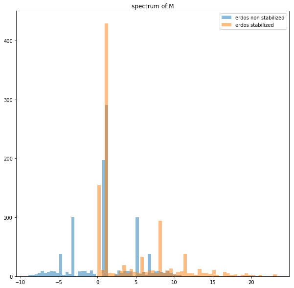

```python
plt.figure(figsize=(10,10))
plt.title('spectrum of M')
plt.hist(erdos_nonst,alpha=0.5,label="erdos non stabilized",bins=50);
plt.hist(erdos_st, alpha=0.5, label="erdos stabilized",bins=50);
plt.legend()
```

```python
ws_nonst = econ2.spectrum()
econ2.stabilize()
ws_st = econ2.spectrum()
```

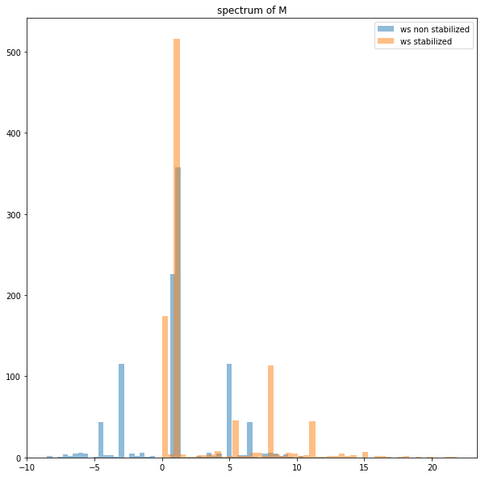

```python
plt.figure(figsize=(10,10))
plt.title('spectrum of M')
plt.hist(ws_nonst,alpha=0.5,label="ws non stabilized",bins=50);
plt.hist(ws_st, alpha=0.5, label="ws stabilized",bins=50);
plt.legend()
```

# Perturbations and avalanches

We now start from a stabilized state and perturb it. We look at the size of "avalanches": the number of prices that become negative after a perturbation.

## Productivity perturbations

Take a random firm $j$, and do $z_j^{p}=z_j^{s} \xi$ where $\xi$ is a random number (i.e. uniform in 0.5,1).

```python
n_trials = 50
n_matrices = 1000
```

```python
erdos_prod_avsizes = av.productivity_avalanches(C,sigma,Q,n_trials,n_matrices,graph_type='erdos',q=0.3,k=k)
```

```
100... 200... 300... 400... 500... 600... 700... 800... 900... 1000...
```

```python
ws_prod_avsizes = av.productivity_avalanches(C,sigma,Q,n_trials,n_matrices,graph_type='ws',q=0.3,k=k,p=p)
```

```
100... 200... 300... 400... 500... 600... 700... 800... 900... 1000...
```

```python
prod_cumsizes_erdos = av.cum_sizes(erdos_prod_avsizes,Q)
prod_cumsizes_ws = av.cum_sizes(ws_prod_avsizes,Q)
```

```
(1, 100000.0)
```

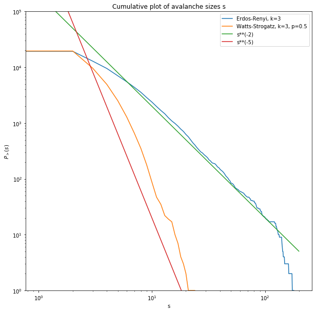

```python
plt.figure(figsize=(10,10))
plt.title("Cumulative plot of avalanche sizes s")
plt.plot(range(Q),prod_cumsizes_erdos,label='Erdos-Renyi, k={}'.format(k))
plt.plot(range(Q),prod_cumsizes_ws,label='Watts-Strogatz, k={}, p={}'.format(k,p))
xs = np.arange(1,Q,dtype=float)
nu=2
plt.plot(xs,2e5*xs**(-nu),label='s**(-{})'.format(nu))
nu2=5
plt.plot(xs,2e6*xs**(-nu2),label='s**(-{})'.format(nu2))
plt.legend()
plt.xscale('log')
plt.yscale('log')
plt.xlabel('s')
plt.ylabel('$P_>(s)$')
plt.ylim(1,1e5)
```

```python
erdos_prod_avsizes2 = av.productivity_avalanches(C,sigma,Q,n_trials,n_matrices,graph_type='erdos',q=0.3,k=6)
ws_prod_avsizes2 = av.productivity_avalanches(C,sigma,Q,n_trials,n_matrices,graph_type='ws',q=0.3,k=6,p=p)
ws_prod_avsizes3 = av.productivity_avalanches(C,sigma,Q,n_trials,n_matrices,graph_type='ws',q=0.3,k=6,p=0.75)
```

```
 100... 200... 300... 400... 500... 600... 700... 800... 900... 1000... 100... 200... 300... 400... 500... 600... 700... 800... 900... 1000... 100... 200... 300... 400... 500... 600... 700... 800... 900... 1000...
```

```python
ws_prod_avsizes4 = av.productivity_avalanches(C,sigma,Q,n_trials,n_matrices,graph_type='ws',q=0.3,k=k,p=0.75)
```

```
100... 200... 300... 400... 500... 600... 700... 800... 900... 1000...
```

```python
prod_cumsizes_erdos2 = av.cum_sizes(erdos_prod_avsizes2,Q)
prod_cumsizes_ws2 = av.cum_sizes(erdos_prod_avsizes2,Q)
prod_cumsizes_ws3 = av.cum_sizes(ws_prod_avsizes3,Q)
```

```python
prod_cumsizes_ws4 = av.cum_sizes(ws_prod_avsizes4,Q)
```

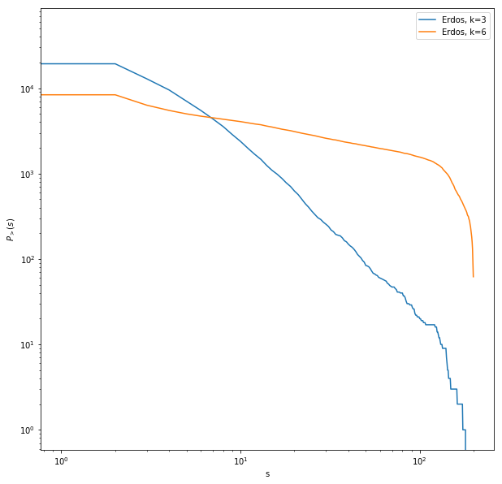

```python
plt.figure(figsize=(10,10))
plt.plot(range(Q),prod_cumsizes_erdos,label='Erdos, k={}'.format(k))
plt.plot(range(Q),prod_cumsizes_erdos2,label='Erdos, k=6')
plt.legend()
plt.xlabel('s')
plt.ylabel('$P_>(s)$')
plt.xscale('log')
plt.yscale('log')
```

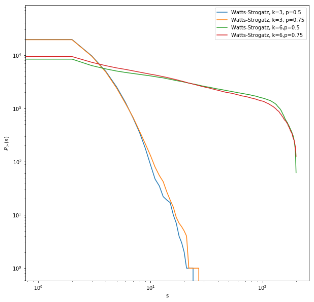

```python
plt.figure(figsize=(10,10))
plt.plot(range(Q),prod_cumsizes_ws,label='Watts-Strogatz, k={}, p={}'.format(k,p))
plt.plot(range(Q),prod_cumsizes_ws4,label='Watts-Strogatz, k={}, p=0.75'.format(k,p))
plt.plot(range(Q),prod_cumsizes_ws2,label='Watts-Strogatz, k=6,p={}'.format(p))
plt.plot(range(Q),prod_cumsizes_ws3,label='Watts-Strogatz, k=6,p=0.75')
plt.legend()
plt.xlabel('s')
plt.ylabel('$P_>(s)$')
plt.xscale('log')
plt.yscale('log')
```

# Graph rewiring avalanches

We can also consider a very simple perturbation: take a link $(i\leftrightarrow j)\in \mathcal{G}$ and pick $(k,l)$ such that $(k\leftrightarrow l)\notin \mathcal{G}$ and "swap" the link so that $$\frac{1}{J_{kl}}\leftarrow \frac{1}{J_{ij}}$$ $$\frac{1}{J_{ij}}\leftarrow 0$$

[figure not shown]